# Individual Assignment - Global Sanitation & Health: A UNICEF Data Story

Produced for Data Analytics and Story Telling (DCU)

Author

Anmol Brijesh Shami - A00054400

Published

April 7, 2026

```python
!pip install polars plotnine geopandas==0.14.4 pycountry-convert pyarrow --quiet
```

# Introduction

Access to **safe sanitation** remains one of the most critical yet under-addressed global challenges. Millions of people lack proper waste treatment, exposing communities to preventable diseases. This report uses UNICEF data to explore **sanitation coverage**, **maternal health indicators**, and **life expectancy** patterns across the globe — revealing the deep connections between infrastructure, health outcomes, and economic development.

```python
import polars as pl
import numpy as np
import geopandas as gpd
from plotnine import *
import pycountry_convert as pc
import warnings
warnings.filterwarnings("ignore")

# ── Custom plotnine theme ──
theme_unicef = (
    theme_minimal()
    + theme(
        plot_title=element_text(size=15, weight="bold", color="#1a3a5c",
                                margin={"b": 6}),
        plot_subtitle=element_text(size=10, color="#666666", style="italic",
                                    margin={"b": 12}),
        axis_title_x=element_text(size=10, color="#444444", margin={"t": 10}),
        axis_title_y=element_text(size=10, color="#444444", margin={"r": 10}),
        axis_text=element_text(size=9, color="#555555"),
        legend_title=element_text(size=10, weight="bold", color="#333333"),
        legend_text=element_text(size=9, color="#444444"),
        legend_background=element_rect(fill="white", alpha=0.8),
        legend_key=element_rect(fill="white", color="white"),
        panel_grid_major=element_line(color="#eeeeee", size=0.4),
        panel_grid_minor=element_blank(),
        plot_background=element_rect(fill="white", color="white"),
        panel_background=element_rect(fill="white"),
        strip_text=element_text(size=10, weight="bold", color="#1a3a5c"),
        plot_margin=0.035,
    )
)

# ── Colour palettes ──
continent_pal = {
    "Africa": "#e63946",
    "Asia": "#457b9d",
    "Europe": "#2a9d8f",
    "North America": "#e9c46a",
    "Oceania": "#f4a261",
    "South America": "#264653",
}
continent_colors = list(continent_pal.values())

map_theme = (
    theme_unicef
    + theme(
        figure_size=(13, 6.5),
        axis_text=element_blank(),
        axis_ticks=element_blank(),
        axis_title=element_blank(),
        panel_grid_major=element_blank(),
    )
)

# ── Load data from Google Drive ──
indicator_1 = pl.read_csv("/content/drive/MyDrive/unicef_indicator_1.csv")
indicator_2 = pl.read_csv("/content/drive/MyDrive/unicef_indicator_2.csv")
metadata = pl.read_csv("/content/drive/MyDrive/unicef_metadata.csv")

# ── Helper: alpha_3 → continent ──
def get_continent(alpha3):
    try:
        alpha2 = pc.country_alpha3_to_country_alpha2(alpha3)
        continent_code = pc.country_alpha2_to_continent_code(alpha2)
        return pc.convert_continent_code_to_continent_name(continent_code)
    except Exception:
        return None

# ── Load world geometries ──
world = gpd.read_file(gpd.datasets.get_path("naturalearth_lowres"))
world = world.rename(columns={"iso_a3": "alpha_3_code"})
```

## Exploring Sanitation Rates Across the World

The map below shows the **proportion of the population using on-site sanitation facilities with human waste treated off-site** by country, averaged over the most recent five years available. Higher values indicate stronger sanitation infrastructure.

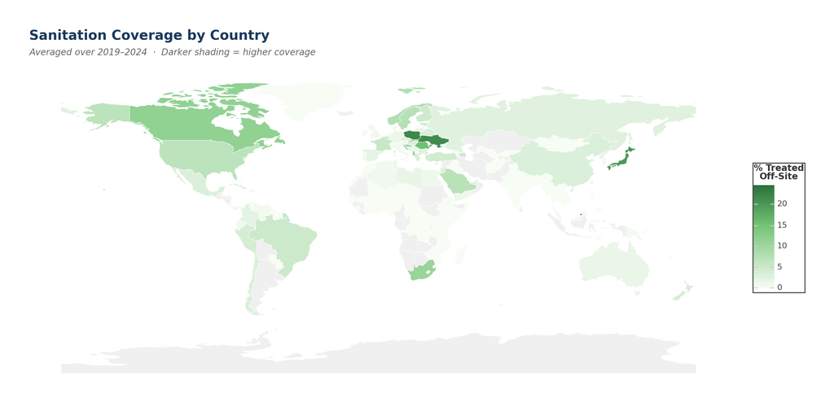

```python
latest = (
    indicator_1
    .filter(pl.col("time_period") >= 2019)
    .group_by("alpha_3_code", "country")
    .agg(pl.col("obs_value").mean().alias("avg_sanitation"))
)

merged = world.merge(latest.to_pandas(), on="alpha_3_code", how="left")

(
    ggplot(merged)
    + geom_map(aes(fill="avg_sanitation"), color="#ffffff", size=0.2)
    + scale_fill_gradient2(
        low="#f7fcf5", mid="#74c476", high="#00441b",
        midpoint=15, na_value="#f0f0f0",
        name="% Treated\nOff-Site"
    )
    + labs(title="Sanitation Coverage by Country",
           subtitle="Averaged over 2019–2024  ·  Darker shading = higher coverage")
    + map_theme
)
```

## Top and Bottom Countries by Sanitation Coverage

Which nations lead in sanitation — and which are falling behind? This chart compares the **top 15** against the **bottom 15** countries.

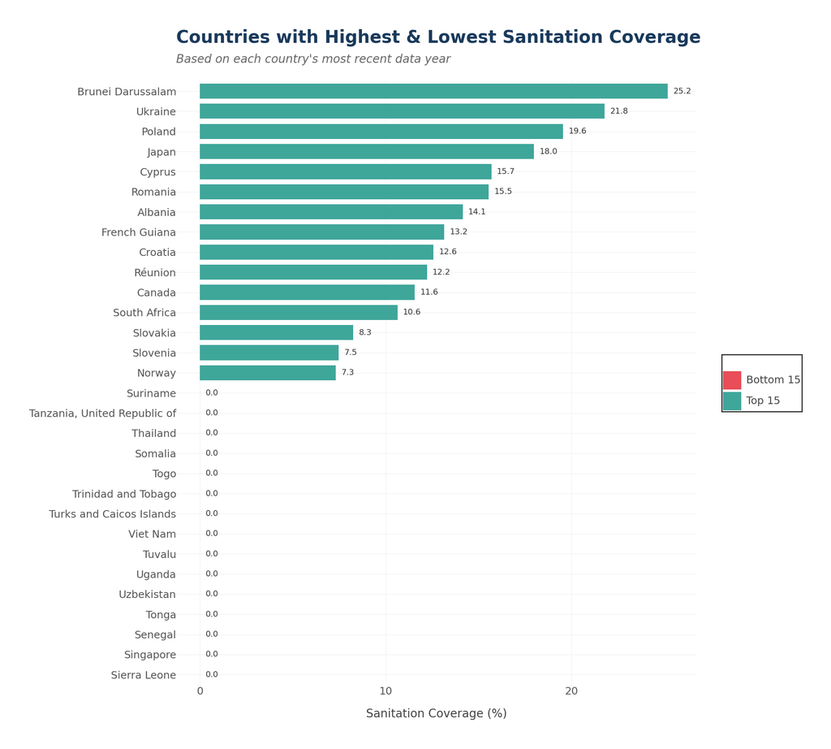

```python
latest_year = (
    indicator_1
    .group_by("country", "alpha_3_code")
    .agg(pl.col("time_period").max().alias("latest_year"))
)

latest_vals = (
    indicator_1
    .join(latest_year, on=["country", "alpha_3_code"])
    .filter(pl.col("time_period") == pl.col("latest_year"))
    .select("country", "obs_value")
    .sort("obs_value", descending=True)
)

top15 = latest_vals.head(15).with_columns(pl.lit("Top 15").alias("group"))
bot15 = latest_vals.tail(15).with_columns(pl.lit("Bottom 15").alias("group"))
bar_df = pl.concat([top15, bot15]).to_pandas()

(
    ggplot(bar_df, aes(x="reorder(country, obs_value)", y="obs_value", fill="group"))
    + geom_col(width=0.75, alpha=0.9)
    + geom_text(
        aes(label="round(obs_value, 1)"),
        ha="left", size=7, nudge_y=0.3, color="#333333"
    )
    + coord_flip()
    + scale_fill_manual(values={"Top 15": "#2a9d8f", "Bottom 15": "#e63946"})
    + labs(x="", y="Sanitation Coverage (%)", fill="",
           title="Countries with Highest & Lowest Sanitation Coverage",
           subtitle="Based on each country's most recent data year")
    + theme_unicef
    + theme(figure_size=(10, 9))
)
```

## Scatterplot: GDP per Capita vs. Sanitation Coverage

Does national wealth translate into better sanitation? The plot below examines this relationship using 2020 data, with each bubble sized by population.

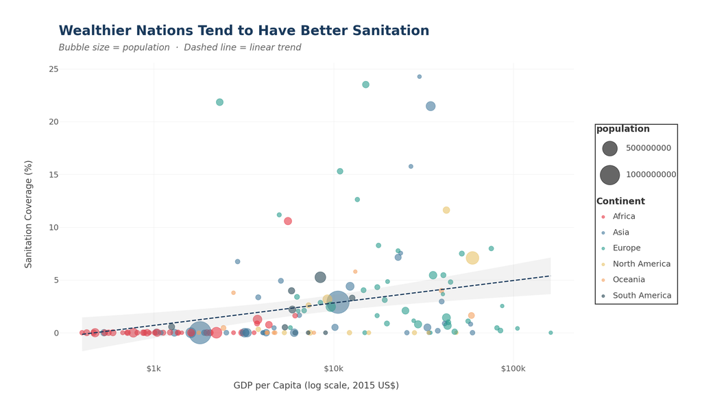

```python
meta_2020 = (
    metadata
    .filter(pl.col("year") == 2020)
    .select("alpha_3_code", "GDP per capita (constant 2015 US$)",
            "Life expectancy at birth, total (years)", "Population, total")
    .rename({"GDP per capita (constant 2015 US$)": "gdp_pc",
             "Life expectancy at birth, total (years)": "life_exp",
             "Population, total": "population"})
)

ind1_2020 = (
    indicator_1
    .filter(pl.col("time_period") == 2020)
    .select("alpha_3_code", "obs_value")
    .rename({"obs_value": "sanitation"})
)

scatter_df = (
    ind1_2020
    .join(meta_2020, on="alpha_3_code")
    .drop_nulls(["gdp_pc", "sanitation"])
)

scatter_pd = scatter_df.to_pandas()
scatter_pd["alpha_3_code"] = scatter_pd["alpha_3_code"].astype(str)
scatter_pd["continent"] = scatter_pd["alpha_3_code"].apply(get_continent)
scatter_pd = scatter_pd.dropna(subset=["continent"])

(
    ggplot(scatter_pd, aes(x="gdp_pc", y="sanitation",
                           color="continent", size="population"))
    + geom_point(alpha=0.6, stroke=0.3)
    + geom_smooth(aes(group=1), method="lm", se=True,
                  color="#1a3a5c", linetype="dashed", size=0.7, alpha=0.12)
    + scale_x_log10(labels=lambda x: [f"${v/1000:.0f}k" for v in x])
    + scale_size_continuous(range=(2, 14))
    + scale_color_manual(values=continent_pal)
    + guides(size=None)
    + labs(x="GDP per Capita (log scale, 2015 US$)",
           y="Sanitation Coverage (%)",
           color="Continent",
           title="Wealthier Nations Tend to Have Better Sanitation",
           subtitle="Bubble size = population  ·  Dashed line = linear trend")
    + theme_unicef
    + theme(figure_size=(11, 6.5))
)
```

## Insights into Global Life Expectancy Trends

### Tracking Life Expectancy Across Continents

Life expectancy has increased globally since 1960, but the pace of progress varies dramatically by region.

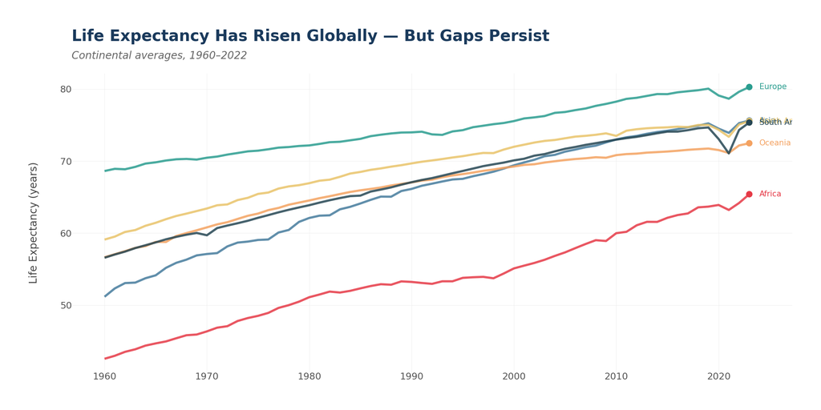

```python
life_ts = (
    metadata
    .select("alpha_3_code", "year", "Life expectancy at birth, total (years)")
    .rename({"Life expectancy at birth, total (years)": "life_exp"})
    .drop_nulls()
    .filter(pl.col("year") >= 1960)
)

life_pd = life_ts.to_pandas()
life_pd["continent"] = life_pd["alpha_3_code"].apply(get_continent)
life_pd = life_pd.dropna(subset=["continent"])

continent_avg = (
    life_pd
    .groupby(["continent", "year"])["life_exp"]
    .mean()
    .reset_index()
)

# Label endpoints
endpoints = continent_avg.loc[
    continent_avg.groupby("continent")["year"].idxmax()
]

(
    ggplot(continent_avg, aes(x="year", y="life_exp", color="continent"))
    + geom_line(size=1.2, alpha=0.85)
    + geom_point(data=endpoints, size=2.5)
    + geom_text(
        data=endpoints,
        mapping=aes(label="continent"),
        ha="left", nudge_x=1, size=7.5, show_legend=False
    )
    + scale_color_manual(values=continent_pal)
    + scale_x_continuous(breaks=range(1960, 2030, 10))
    + labs(x="", y="Life Expectancy (years)", color="Continent",
           title="Life Expectancy Has Risen Globally — But Gaps Persist",
           subtitle="Continental averages, 1960–2022")
    + theme_unicef
    + theme(figure_size=(11, 5.5), legend_position="none")
)
```

### Mapping Global Life Expectancy

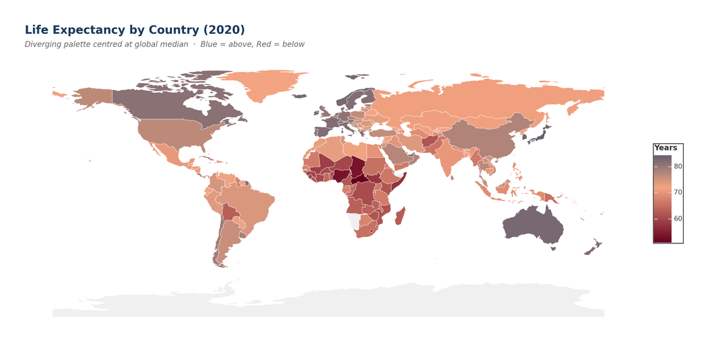

```python
life_2020 = (
    metadata
    .filter(pl.col("year") == 2020)
    .select("alpha_3_code", "Life expectancy at birth, total (years)")
    .rename({"Life expectancy at birth, total (years)": "life_exp"})
    .drop_nulls()
)

merged_life = world.merge(life_2020.to_pandas(), on="alpha_3_code", how="left")

(
    ggplot(merged_life)
    + geom_map(aes(fill="life_exp"), color="#ffffff", size=0.2)
    + scale_fill_gradient2(
        low="#67001f", mid="#f4a582", high="#053061",
        midpoint=72, na_value="#f0f0f0",
        name="Years"
    )
    + labs(title="Life Expectancy by Country (2020)",
           subtitle="Diverging palette centred at global median  ·  Blue = above, Red = below")
    + map_theme
)
```

## Maternal Health: HIV Testing at Antenatal Clinics

The second UNICEF indicator tracks the **number of pregnant women tested for HIV** at antenatal clinics. The bar chart below highlights the countries with the highest reported numbers.

[figure not shown]

```python
hiv_latest = (
    indicator_2
    .group_by("country")
    .agg([
        pl.col("obs_value").last().alias("tested"),
        pl.col("time_period").max().alias("year")
    ])
    .sort("tested", descending=True)
    .head(20)
)

hiv_pd = hiv_latest.to_pandas()

(
    ggplot(hiv_pd, aes(x="reorder(country, tested)", y="tested"))
    + geom_col(fill="#6a51a3", width=0.75, alpha=0.9)
    + geom_text(
        aes(label=[f"{v/1e6:.1f}M" if v >= 1e6 else f"{v/1e3:.0f}K"
                    for v in hiv_pd.sort_values("tested")["tested"]]),
        ha="left", size=7, nudge_y=5000, color="#333333"
    )
    + coord_flip()
    + scale_y_continuous(
        labels=lambda x: [f"{v/1e6:.1f}M" if v >= 1e6 else f"{v/1e3:.0f}K" for v in x]
    )
    + labs(x="", y="Number of Pregnant Women Tested",
           title="HIV Testing at Antenatal Clinics — Leading Countries",
           subtitle="Most recent year available per country")
    + theme_unicef
    + theme(figure_size=(10, 8))
)
```